# ReCell Project

# Checking Linear Regression Assumptions

**In order to make statistical inferences from a linear regression model, it is important to ensure that the assumptions of linear regression are satisfied.**

The following Linear Regression assumptions will be checked:

- No Multicollinearity
- Linearity of variables
- Independence of error terms
- Normality of error terms
- No Heteroscedasticity

### a) TEST FOR MULTICOLLINEARITY

- Multicollinearity occurs when predictor variables in a regression model are correlated.
- This correlation is a problem because predictor variables should be independent.
- **Variance Inflation Factor (VIF)** is being used to test for multicollinearity.
  - If VIF is 1, then there is no correlation among the 𝑘 th predictor and the remaining predictor variables, and hence, the variance of 𝛽𝑘 is not inflated at all.
- **General Rule of thumb:**
  - If VIF is between 1 and 5, then there is low multicollinearity.
  - If VIF is between 5 and 10, we say there is moderate multicollinearity.
  - If VIF is exceeding 10, it shows signs of high multicollinearity.

```python
pd.set_option("display.float_format", lambda x: "%.5f" % x)
```

```python
from statsmodels.stats.outliers_influence import variance_inflation_factor

# Define a function to check VIF
def checking_vif(predictors):
    vif = pd.DataFrame()
    vif["feature"] = predictors.columns

    # Calculating VIF for each feature
    vif["VIF"] = [
        variance_inflation_factor(predictors.values, i)
        for i in range(len(predictors.columns))
    ]
    return vif
```

```python
checking_vif(x_train1)
```

|  | feature | VIF |
| --- | --- | --- |
| 0 | const | 3288870.80585 |
| 1 | screen_size | 3.22347 |
| 2 | main_camera_mp | 1.83930 |
| 3 | selfie_camera_mp | 2.64197 |
| 4 | int_memory | 1.19765 |
| 5 | ram | 1.66703 |
| 6 | battery | 3.59751 |
| 7 | weight | 3.04191 |
| 8 | release_year | 4.27303 |
| 9 | days_used | 2.54751 |
| 10 | os_Others | 1.35064 |
| 11 | os_Windows | 1.02407 |
| 12 | os_iOS | 1.08205 |
| 13 | 4g_1 | 2.17244 |
| 14 | 5g_1 | 1.68937 |
| 15 | price_bin_Mid-range phones | 2.23925 |
| 16 | price_bin_High-range phones | 2.89566 |

#### Findings

- Since all the variables have a VIF < 5, it can be said that the above predictors have no multicollinearity.
- The first assumption of **no multicollinearity is satisfied.**

### TEST FOR LINEARITY AND INDEPENDENCE

- Linearity describes a straight-line relationship between two variables, predictor variables must have a linear relation with the dependent variable.
- Also, the independence of the error terms (or residuals) is important.
- A plot of fitted values vs residuals would help gauge if there is presence of a pattern in the data and if it is showing signs of non-linearity and residuals are not independent.
- If present, this will be fixed by trying to transform the variables and making the relationships linear.

```python
# let us create a dataframe with actual, fitted and residual values
phone_pred = pd.DataFrame()

phone_pred["Actual Values"] = y_train  # actual values
phone_pred["Fitted Values"] = olsmod0.fittedvalues  # predicted values
phone_pred["Residuals"] = olsmod0.resid  # residuals

phone_pred.head()
```

|  | Actual Values | Fitted Values | Residuals |
| --- | --- | --- | --- |
| 844 | 100.48000 | 77.20083 | 23.27917 |
| 1539 | 111.68000 | 87.04218 | 24.63782 |
| 3452 | 113.89000 | 136.45005 | -22.56005 |
| 1727 | 64.09000 | 84.78865 | -20.69865 |
| 1926 | 67.95000 | 69.15739 | -1.20739 |

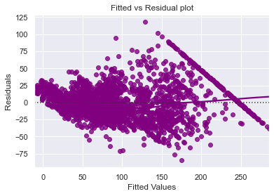

```python
# let's plot the fitted values vs residuals

sns.residplot(
    data=phone_pred, x="Fitted Values", y="Residuals", color="purple", lowess=True
)
plt.xlabel("Fitted Values")
plt.ylabel("Residuals")
plt.title("Fitted vs Residual plot")
plt.show()
```

#### Findings

- The scatter plot shows the distribution of residuals (errors) vs fitted values (predicted values).
- Since there exists a pattern in this plot, we consider it as signs of non-linearity in the data, which will need to be treated by **transforming the variables and make the relationships linear.**

### Removing non-linearity and dependence of residuals

To fix this assumption:

- We will try to transform the study variables, first target/dependent variable, used_price using log transformation.
  - Since the distribution of used_price is highly skewed, log transformation is being employed so that the variable behaves better and gets closer to a near normal distribution.
- Transformation is always tried in dependent variables first because the residuals that cause heteroscedasticity is because of dependent variable and not the independent features.
- If required after this, we will try to transform the independent variables as well, using log transformation.
- We will then look at the scatter plot of the distribution of residuals (errors) vs fitted values (predicted values) again and then run the model.

#### Transforming the dependent variable, used_price

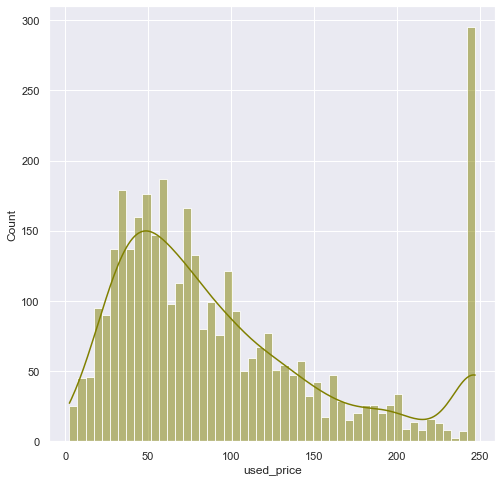

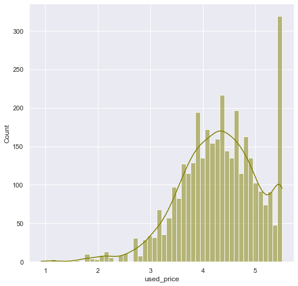

```python
# Since there are no non-positive values, simple log can be applied

# Looking at the original distribution first
plt.figure(figsize=(8, 8))
sns.histplot(phone["used_price"], bins=50, kde=True, color="olive")
plt.show()

# Looking at the log transformed distribution next
target = np.log(phone["used_price"])

plt.figure(figsize=(8, 8))
sns.histplot(target, bins=50, kde=True, color="olive")
plt.show()
```

```python
cols_to_log = ["used_price"]
for colname in cols_to_log:
    phone[colname + "_log"] = np.log(phone[colname])
phone.drop(cols_to_log, axis=1, inplace=True)
```

#### Re-running the statsmodel with used_price_log

```python
# defining X and y variables

X1 = phone.drop(["used_price_log", "brand_name"], axis=1)
y1 = phone["used_price_log"]

print(X1.head())
print(y1.head())
```

```
        os  screen_size 4g 5g  main_camera_mp  selfie_camera_mp  int_memory  \
0  Android      8.75000  1  0        13.00000           5.00000    64.00000
1  Android      8.75000  1  1        13.00000          16.00000   128.00000
2  Android      8.75000  1  1        13.00000           8.00000   128.00000
3  Android      8.75000  1  1        13.00000           8.00000    64.00000
4  Android      6.19000  1  0        13.00000           8.00000    64.00000

      ram    battery    weight  release_year  days_used  \
0 3.00000 3020.00000 146.00000          2020        127
1 8.00000 4300.00000 213.00000          2020        325
2 8.00000 4200.00000 213.00000          2020        162
3 6.00000 6850.00000 250.00000          2020        345
4 3.00000 5000.00000 185.00000          2020        293

                 price_bin
0  Low-range/Budget phones
1         Mid-range phones
2        High-range phones
3         Mid-range phones
4         Mid-range phones
0   4.46545
1   5.08444
2   5.51017
3   5.19423
4   4.64247
Name: used_price_log, dtype: float64
```

```python
# One-hot encoding for categorical variables

X1 = pd.get_dummies(
    X1, columns=X1.select_dtypes(include=["category"]).columns.tolist(), drop_first=True
)
X1.head()
```

|  | screen_size | main_camera_mp | selfie_camera_mp | int_memory | ram | battery | weight | release_year | days_used | os_Others | os_Windows | os_iOS | 4g_1 | 5g_1 | price_bin_Mid-range phones | price_bin_High-range phones |
| --- | --- | --- | --- | --- | --- | --- | --- | --- | --- | --- | --- | --- | --- | --- | --- | --- |
| 0 | 8.75000 | 13.00000 | 5.00000 | 64.00000 | 3.00000 | 3020.00000 | 146.00000 | 2020 | 127 | 0 | 0 | 0 | 1 | 0 | 0 | 0 |
| 1 | 8.75000 | 13.00000 | 16.00000 | 128.00000 | 8.00000 | 4300.00000 | 213.00000 | 2020 | 325 | 0 | 0 | 0 | 1 | 1 | 1 | 0 |
| 2 | 8.75000 | 13.00000 | 8.00000 | 128.00000 | 8.00000 | 4200.00000 | 213.00000 | 2020 | 162 | 0 | 0 | 0 | 1 | 1 | 0 | 1 |
| 3 | 8.75000 | 13.00000 | 8.00000 | 64.00000 | 6.00000 | 6850.00000 | 250.00000 | 2020 | 345 | 0 | 0 | 0 | 1 | 1 | 1 | 0 |
| 4 | 6.19000 | 13.00000 | 8.00000 | 64.00000 | 3.00000 | 5000.00000 | 185.00000 | 2020 | 293 | 0 | 0 | 0 | 1 | 0 | 1 | 0 |

```python
# splitting the data in 70:30 ratio for train to test data

x1_train, x1_test, y1_train, y1_test = train_test_split(
    X1, y1, test_size=0.3, random_state=42
)
```

```python
# Building and fitting the model on the train data (70% of the whole data)

linearregression = LinearRegression()
linearregression.fit(x1_train, y1_train)
```

```
LinearRegression()
```

```python
# unlike sklearn, statsmodels does not add a constant to the data on its own
# we have to add the constant manually
x1_train1 = sm.add_constant(x1_train)
# adding constant to the test data
x1_test1 = sm.add_constant(x1_test)

olsmod1 = sm.OLS(y1_train, x1_train1).fit()
print(olsmod1.summary())
```

```
                            OLS Regression Results
==============================================================================
Dep. Variable:         used_price_log   R-squared:                       0.868
Model:                            OLS   Adj. R-squared:                  0.867
Method:                 Least Squares   F-statistic:                     1017.
Date:                Sat, 21 Aug 2021   Prob (F-statistic):               0.00
Time:                        04:45:36   Log-Likelihood:                -349.59
No. Observations:                2499   AIC:                             733.2
Df Residuals:                    2482   BIC:                             832.2
Df Model:                          16
Covariance Type:            nonrobust
===============================================================================================
                                  coef    std err          t      P>|t|      [0.025      0.975]
-----------------------------------------------------------------------------------------------
const                          54.3521     10.131      5.365      0.000      34.487      74.218
screen_size                     0.0138      0.006      2.262      0.024       0.002       0.026
main_camera_mp                  0.0185      0.002     11.590      0.000       0.015       0.022
selfie_camera_mp                0.0062      0.001      4.729      0.000       0.004       0.009
int_memory                  -9.634e-05   7.18e-05     -1.341      0.180      -0.000    4.45e-05
ram                             0.0280      0.005      5.361      0.000       0.018       0.038
battery                     -2.157e-06   8.43e-06     -0.256      0.798   -1.87e-05    1.44e-05
weight                          0.0009      0.000      3.950      0.000       0.000       0.001
release_year                   -0.0251      0.005     -4.988      0.000      -0.035      -0.015
days_used                      -0.0011   3.56e-05    -31.682      0.000      -0.001      -0.001
os_Others                      -0.4742      0.027    -17.458      0.000      -0.527      -0.421
os_Windows                     -0.0172      0.041     -0.418      0.676      -0.098       0.064
os_iOS                          0.3108      0.048      6.461      0.000       0.216       0.405
4g_1                            0.0683      0.017      3.946      0.000       0.034       0.102
5g_1                           -0.0497      0.037     -1.361      0.174      -0.121       0.022
price_bin_Mid-range phones      0.6786      0.017     40.590      0.000       0.646       0.711
price_bin_High-range phones     1.2919      0.022     58.666      0.000       1.249       1.335
==============================================================================
Omnibus:                      319.852   Durbin-Watson:                   1.988
Prob(Omnibus):                  0.000   Jarque-Bera (JB):             1392.762
Skew:                          -0.551   Prob(JB):                    3.68e-303
Kurtosis:                       6.488   Cond. No.                     6.95e+06
==============================================================================

Notes:
[1] Standard Errors assume that the covariance matrix of the errors is correctly specified.
[2] The condition number is large, 6.95e+06. This might indicate that there are
strong multicollinearity or other numerical problems.
```

```python
# let us create a dataframe with actual, fitted and residual values
phone_pred1 = pd.DataFrame()

phone_pred1["Actual Values"] = y1_train  # actual values
phone_pred1["Fitted Values"] = olsmod1.fittedvalues  # predicted values
phone_pred1["Residuals"] = olsmod1.resid  # residuals

phone_pred1.head()
```

|  | Actual Values | Fitted Values | Residuals |
| --- | --- | --- | --- |
| 844 | 4.60996 | 4.23511 | 0.37485 |
| 1539 | 4.71564 | 4.42295 | 0.29269 |
| 3452 | 4.73523 | 4.98619 | -0.25096 |
| 1727 | 4.16029 | 4.44787 | -0.28758 |
| 1926 | 4.21877 | 4.10142 | 0.11736 |

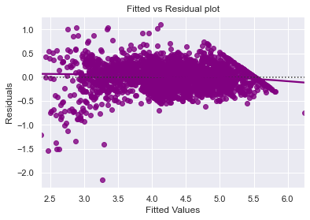

```python
# let's plot the fitted values vs residuals

sns.residplot(
    data=phone_pred1, x="Fitted Values", y="Residuals", color="purple", lowess=True
)
plt.xlabel("Fitted Values")
plt.ylabel("Residuals")
plt.title("Fitted vs Residual plot")
plt.show()
```

### TEST FOR NORMALITY

- Error terms, or residuals, should be normally distributed. Non-normality suggests that there are a few unusual data points that must be studied closely to make a better model.
- The shape of the histogram of residuals can give an initial idea about the normality.
- Further, normality will be checked via a Q-Q plot of residuals. If the residuals follow a normal distribution, they will make a straight line plot, otherwise not.
- The Shapiro-Wilk test statistic will also be calculated.
  - Null hypothesis: Residuals are normally distributed
  - Alternate hypothesis: Residuals are not normally distributed

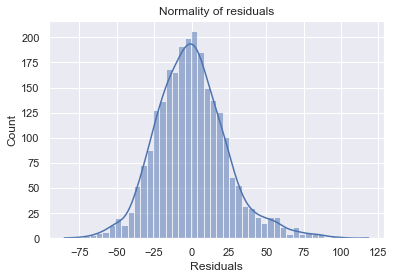

```python
# Plotting histogram with kde to gauge normality

sns.histplot(data=phone_pred, x="Residuals", kde=True)
plt.title("Normality of residuals")
plt.show()
```

- The histogram of residuals does have a bell shape.
- Let's check the Q-Q plot.

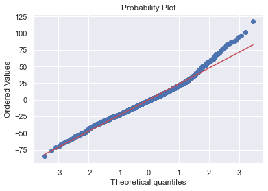

```python
# Plotting a Q-Q plot for checking normality of residuals

import pylab
import scipy.stats as stats

stats.probplot(phone_pred["Residuals"], dist="norm", plot=pylab)
plt.show()
```

- The residuals more or less follow a straight line except for the upper tail.
- Let's check the results of the Shapiro-Wilk test.

```python
# Calculating the Shapiro-Wilk test statistic

stats.shapiro(phone_pred["Residuals"])
```

```
ShapiroResult(statistic=0.9815012812614441, pvalue=1.617643835767684e-17)
```

#### Findings

- Since p-value < 0.05, the residuals are not normal as per the Shapiro-Wilk test.
- However, as an approximation, we can accept this distribution as close to being normal.
- So, the **assumption is satisfied**.

### TEST FOR HOMOSCEDASTICITY

- The presence of non-constant variance in the error terms results in heteroscedasticity. Generally, non-constant variance arises in presence of outliers.
- The **residual vs fitted values plot** created earlier will be looked into again to check for homoscedasticity. In the case of heteroscedasticity, the residuals can form an arrow shape or any other non-symmetrical shape.
- The **goldfeldquandt test** will also be used. If we get a p-value > 0.05 we can say that the residuals are homoscedastic. Otherwise, they are heteroscedastic.
  - Null hypothesis: Residuals are homoscedastic
  - Alternate hypothesis: Residuals have heteroscedasticity

```python
# Employing the goldfeldquandt test to check for heteroscedasticity

import statsmodels.stats.api as sms
from statsmodels.compat import lzip

name = ["F statistic", "p-value"]
test = sms.het_goldfeldquandt(phone_pred["Residuals"], x_train1)
lzip(name, test)
```

```
[('F statistic', 1.0059235900636918), ('p-value', 0.4587197613914659)]
```

#### Findings

Since **p-value > 0.05**, we can say that the residuals are homoscedastic. So, this **assumption is satisfied.**

## Final Model Summary

**Now that we have checked all the assumptions of linear regression and they are satisfied, we can move towards the prediction part.**

For predictions from the model, since the dependent variable was transformed on a logarithmic scale, we need to "back transform" which means applying the inverse of the transformation.

```python
# predictions on the test set
pred = olsmod1.predict(x1_test1)

phone_pred_test = pd.DataFrame({"Actual": y1_test, "Predicted": pred})
# Appling exponential function to reverse the effect of log
np.exp(phone_pred_test.sample(10, random_state=42))
```

|  | Actual | Predicted |
| --- | --- | --- |
| 3151 | 35.98000 | 26.12158 |
| 631 | 188.27000 | 172.74085 |
| 2372 | 51.92000 | 75.49619 |
| 1618 | 20.53000 | 33.13237 |
| 2895 | 40.17000 | 40.05392 |
| 2338 | 47.88000 | 23.70517 |
| 3563 | 247.19250 | 263.96170 |
| 3565 | 247.19250 | 268.38719 |
| 1593 | 35.92000 | 34.85389 |
| 818 | 120.20000 | 91.03867 |

- We can observe here that the model has returned pretty good prediction results, and the actual and predicted values are comparable.
- We can also visualize comparison result as a bar graph, taking a sample of 25 records.

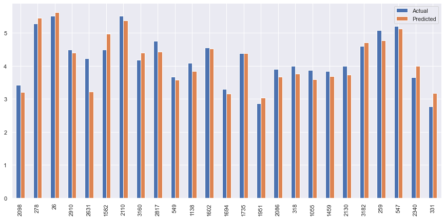

```python
ch = phone_pred_test.sample(25, random_state=1)
ch.plot(kind="bar", figsize=(15, 7))
plt.show()
```

```python
# checking model performance on train set (seen 70% data)

print("Training Performance\n")
olsmod1_train_perf = model_performance_regression(olsmod1, x1_train1, y1_train)
olsmod1_train_perf
```

```
Training Performance
```

|  | RMSE | MAE | R-squared | Adj. R-squared | MAPE |
| --- | --- | --- | --- | --- | --- |
| 0 | 0.27830 | 0.21318 | 0.86765 | 0.86674 | 5.68707 |

```python
# checking model performance on test set (seen 30% data)

print("Test Performance\n")
olsmod1_test_perf = model_performance_regression(olsmod1, x1_test1, y1_test)
olsmod1_test_perf
```

```
Test Performance
```

|  | RMSE | MAE | R-squared | Adj. R-squared | MAPE |
| --- | --- | --- | --- | --- | --- |
| 0 | 0.26171 | 0.20573 | 0.87621 | 0.87421 | 5.24576 |

- The model is able to explain 86.6% of the variation in the data, which is very good.
- The train and test RMSE and MAE are low and comparable. So, our model is not suffering from overfitting.
- The MAPE on the test set suggests we can predict within 5.2% of the used_price, down from 26.5%, which is good.
- Hence, we can conclude the model *olsmod1* is good for prediction as well as inference purposes.

```python
olsmodel_final = sm.OLS(y1_train, x1_train1).fit()
print(olsmodel_final.summary())
```

```
                            OLS Regression Results
==============================================================================
Dep. Variable:         used_price_log   R-squared:                       0.868
Model:                            OLS   Adj. R-squared:                  0.867
Method:                 Least Squares   F-statistic:                     1017.
Date:                Sat, 21 Aug 2021   Prob (F-statistic):               0.00
Time:                        04:45:38   Log-Likelihood:                -349.59
No. Observations:                2499   AIC:                             733.2
Df Residuals:                    2482   BIC:                             832.2
Df Model:                          16
Covariance Type:            nonrobust
===============================================================================================
                                  coef    std err          t      P>|t|      [0.025      0.975]
-----------------------------------------------------------------------------------------------
const                          54.3521     10.131      5.365      0.000      34.487      74.218
screen_size                     0.0138      0.006      2.262      0.024       0.002       0.026
main_camera_mp                  0.0185      0.002     11.590      0.000       0.015       0.022
selfie_camera_mp                0.0062      0.001      4.729      0.000       0.004       0.009
int_memory                  -9.634e-05   7.18e-05     -1.341      0.180      -0.000    4.45e-05
ram                             0.0280      0.005      5.361      0.000       0.018       0.038
battery                     -2.157e-06   8.43e-06     -0.256      0.798   -1.87e-05    1.44e-05
weight                          0.0009      0.000      3.950      0.000       0.000       0.001
release_year                   -0.0251      0.005     -4.988      0.000      -0.035      -0.015
days_used                      -0.0011   3.56e-05    -31.682      0.000      -0.001      -0.001
os_Others                      -0.4742      0.027    -17.458      0.000      -0.527      -0.421
os_Windows                     -0.0172      0.041     -0.418      0.676      -0.098       0.064
os_iOS                          0.3108      0.048      6.461      0.000       0.216       0.405
4g_1                            0.0683      0.017      3.946      0.000       0.034       0.102
5g_1                           -0.0497      0.037     -1.361      0.174      -0.121       0.022
price_bin_Mid-range phones      0.6786      0.017     40.590      0.000       0.646       0.711
price_bin_High-range phones     1.2919      0.022     58.666      0.000       1.249       1.335
==============================================================================
Omnibus:                      319.852   Durbin-Watson:                   1.988
Prob(Omnibus):                  0.000   Jarque-Bera (JB):             1392.762
Skew:                          -0.551   Prob(JB):                    3.68e-303
Kurtosis:                       6.488   Cond. No.                     6.95e+06
==============================================================================

Notes:
[1] Standard Errors assume that the covariance matrix of the errors is correctly specified.
[2] The condition number is large, 6.95e+06. This might indicate that there are
strong multicollinearity or other numerical problems.
```

### Form the statsmodel, the equation of linear regression for preciting the price of a used phone would be:

**y** = 54.3521 + 0.013830 *screen_size + 0.018524* main_camera_mp + 0.006163 *selfie_camera_mp + (-0.000096)* int_memory + 0.027958 *ram + (-0.000002)* battery + 0.000946 *weight + (-0.025060)* release_year + (-0.001127) *days_used + (-0.474217)* os_Others + (-0.017230) *os_Windows + 0.310841* os_iOS + 0.068326 *4g_1 + (-0.049709)* 5g_1 + 0.678617 *price_bin_Mid-range phones + 1.291879* price_bin_High-range phones

## Conclusions - Interpretation of above Regression Results

- Looking at the **Adjusted. R-squared**, we get to know the fit of the model.
  - The value for Adj. R-squared is **0.867**, which is high and indicates a good fit. It means 86.7 % of the variation in the dependent/target variable, used_price, is explained by the independent/predictor variables.
- The value of the *const* coefficient/Y-intercept is **54.3521**
- Looking at the coefficients of predictors, **screen_size, main_camera_mp, selfie_camera_mp, ram, weight, os_iOS, 4g_1, price_bin_Mid-range phones and price_bin_High-range phones** have **positive coefficients**. This means as these increase, used_price also increases.
- **int_memory, battery, release_year, days_used, os_Others, os_Windows and 5g_1** have **negative coefficients**. This implies a negative relationship between these variables and used_price.
- Looking at the p-values for the predictors, their significance can be checked at 0.05 (5%) significance level. A p-value of **less than 0.05** is considered to be statistically significant.
  - **int_memory, battery, os_Windows and 5g_1** are the only variables that are **not significant**. Consequently, they do not make much contribution to the prediction of used_price.
  - **main_camera_mp, selfie_camera_mp, ram, weight, release_year, days_used, os_Others, os_iOS, 4g_1, price_bin_Mid-range phones and price_bin_High-range phones** have come out to be **very significant** and influence the used_price greatly.
  - **screen_size** with a p-value of 0.024 is also a **significant** variable in predicting price of a used phone.

## Key Insights based on EDA

- **Android devices** dominate the used phone market to the extent of over **90 percent.**
- **OnePlus, Apple and Google**, in that order, have the most **expensive phones.**
- 82 percent used phones that form a part of the sample have a ram of 4GB.
- Although **iOS** devices at 1.6 percent form the least share of the used phone market, the **most expensive phones** run on iOS, and fetch twice the price as compared to the second most expensive - Android phones.
- In fact, there are **no low-range/budget phone that run on iOS**, which implies that every iOS device sold fetches more money for the seller as compared to selling phones operating on other operating systems.
- Three bins, namely, **Low-range/Budget phones, Mid-range phones and High-range phones** were created based on the new_price. These correspond to Low-Cost Brands, Mid-Range Brands and High-End Brands respectively.
- The gradual slope of the graph for **low-range/budget** used phones indicates that there is **less variation in the price** for this category as compared to mid-range and high-range phones.
- The **least expensive** high-range and mid-range phones run on **Windows** and 5G is not available in low-range/budget phones.
- The used phone price has a relatively strong **positive correlation** with **selfie_camera_mp, ram and screen_size**, signifying that a higher selfie_camera_mp, a higher ram and a bigger screen_size translate into a higher used_price.
- It was observed that very few low-range/budget phones have good quality selfie cameras. This should be kept in mind while targeting the desired customers.
- The used phone price has a **negative correlation** with **days_used**, which is logical as greater the number of days a phone has been already used for, lower should be its price.

## Actionable Insights and Recommendations

- ReCell, being a startup, should focus on building a wide customer base by way of **Penetration Pricing.** This would entail initially making available a wide variety of low-cost phones to the customers, with a view to building visibility and reception.
- ReCell could engage in **customer segmentation** based on preference for low-cost phones, mid-range phones and high-priced phones by its customers.
- As price variation is the least for low-cost phones, ReCell should devise a **dynamic pricing strategy** for mid-range phones and high-priced phones.
- As **Android devices** dominate the used phone market, ReCell should maintain sufficient inventory based on a market **demand-supply analysis**.
- As iOS devices are the most expensive and cater to a niche segment of customers, ReCell should be mindful of holding a lot of high-value inventory at the outset, before estimating the spending capacity of their prospective customers.
- If however the current demand is for **high-cost and feature-rich phones**, ReCell could leverage such demand by selling **iOS devices** as an average iOS phone fetches more than **double the price** of any other phone.
- **Bigger screens, higher ram and better quality camera** (significantly influence the used_price) are features that customers look for in a phone. ReCell should keep this is in mind while planning its inventory management.
- As newer phones fetch a higher price, ReCell should aim at assigning **cut-off dates for clearing off old inventory**.
- To create an exclusive experience to its customers and contain conpetition from online marketplaces, along with a physical storefront ReCell should build an online presence as well.

# ------------------------------------------**The End**---------------------------------------